# investigating the exponential distribution

Daniel Aklilu

2025-07-23

## Overview:

In this project we will be exploring statistical inference through two components: a simulation study and an analysis of real-world data. In the first part, we use simulated exponential data to demonstrate the Central Limit Theorem. In the second part, we analyzw the ToothGrowth dataset using exploratory plots and hypothesis test to assess the effects of supplement type and dosage on tooth growth.

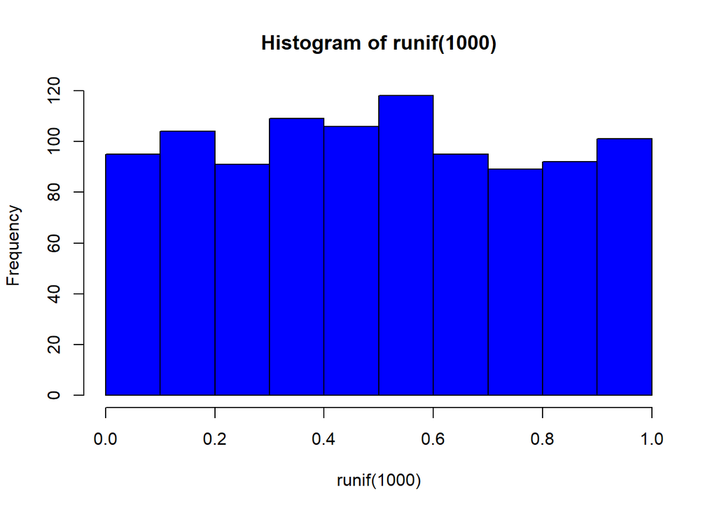

```r
#get histogram of 1000 random samples
hist(runif(1000), col = "blue")
```

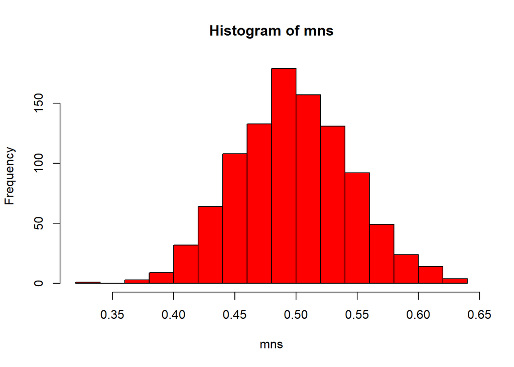

```r
#set mns equal to empty vector
mns = NULL
#itrates though 1000 samples,
#and generates 40 random valjues in each iteration,
#Computes their mean, and appends it to the vector mns.
for(i in 1:1000)mns = c(mns, mean(runif(40)))
# Plot a histogram of 1000 sample means
hist(mns, col = "red")
```

## Simulate one Sample of 40 exponentials

```r
library(tidyverse)
```

```r
library(dplyr)
library(ggplot2)
#install.packages("tinytext", repos = "https://cloud.r-projects.org/")
#tinytex::install_tinytex()
tinytex::tinytex_root()
# varaible declaration
lambda <- 0.2
simulation <- 1000
size <- 40

# Simulate and Store Sample Means
mean_size <- rexp(size, rate = lambda)
# Simulates 1000 times and stores the mean of each sample.
mean_loop <- sapply(1:simulation, function(i) mean(rexp(size,rate = lambda)))
```

## Simulation of Sample Means and Normality Check

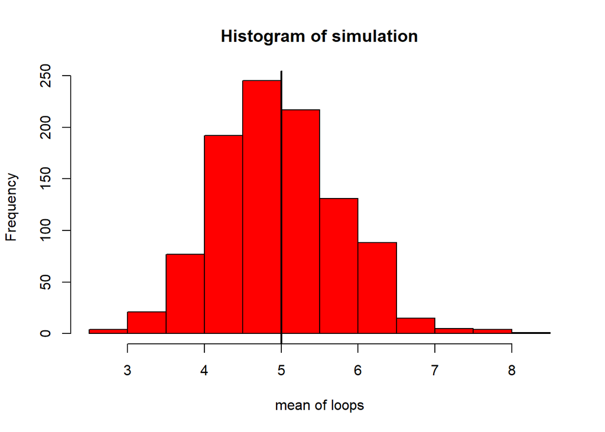

```r
#Check the sample mean
sim_avg <- mean(mean_loop)

#Check the sample variance
sam_var <- var(mean_loop)

#Plot the distribtion
hist(mean_loop, col = "red",
     main = "Histogram of simulation",
     xlab = "mean of loops")
# Add a vertical reference line at the
# true mean (e.g., population mean = 5)
abline(v = 5, col = "black", lwd =2)
```

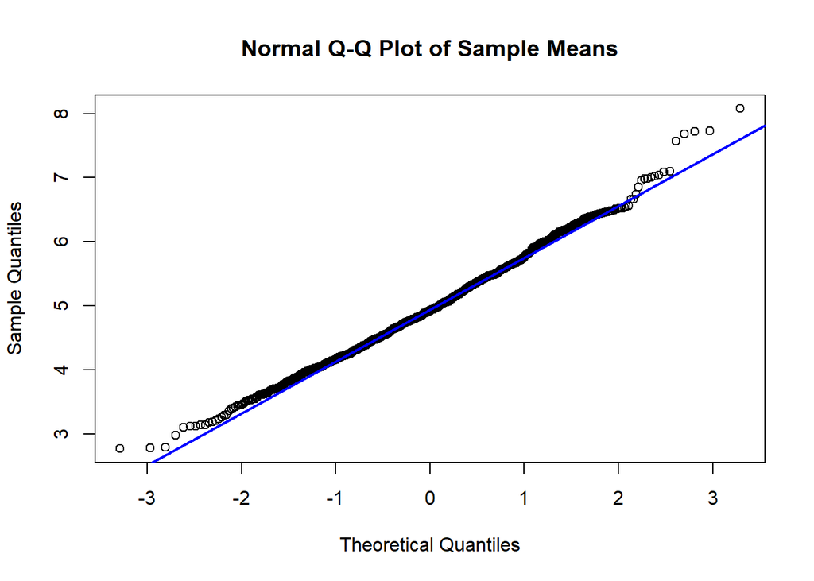

```r
# Create a Q-Q plot to check for normality of the sample
# means. If points fall along the line, the
# distribution is approximately normal.
qqnorm(mean_loop, main= "Normal Q-Q Plot of Sample Means")
qqline(mean_loop, col = "blue", lwd =2)
```

```r
# returns the mean of sim_avg
  sim_avg
```

```
## [1] 4.970924
```

```r
# returns the variance of sam_var
  sam_var
```

```
## [1] 0.6488954
```

## Analyze tooth growth dataset

```r
head(ToothGrowth,10)
summary(ToothGrowth)
str(ToothGrowth)

var(ToothGrowth)

sapply(ToothGrowth[, c("len","dose")], var)
```

[output not shown]

## Plotting Tooth Length by Supplement Type

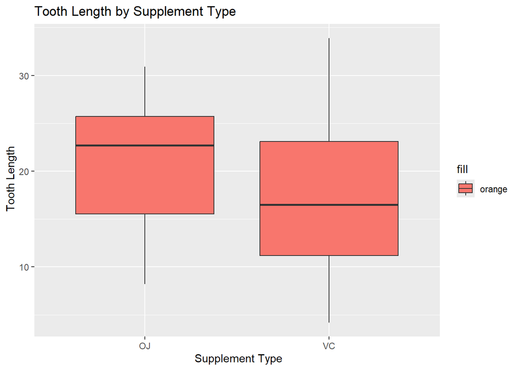

```r
# This plot compares overall tooth length between the two supplement groups (OJ and VC)
# ignoring the effect of dosage.
ggplot(ToothGrowth, aes(x= supp, y = len, fill = "orange")) + geom_boxplot() + labs(title = "Tooth Length by Supplement Type", x = " Supplement Type", y = " Tooth Length")
```

## Plotting Tooth Length by Dose Type

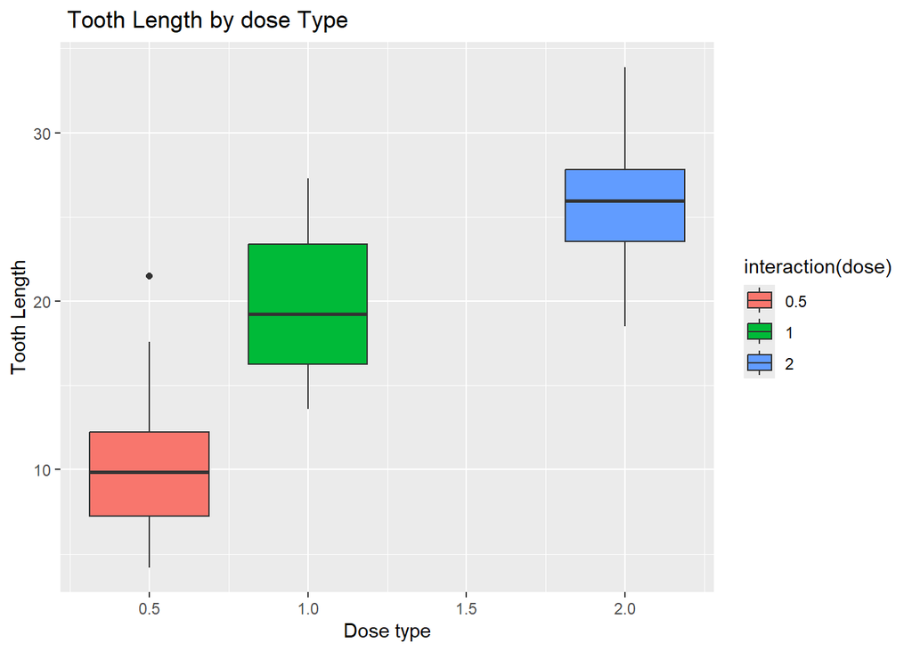

```r
# This plot shows how tooth length varies by both supplement type(OJ vs VC)
# and dosage at (0.5, 1.0, 2.0 mg/day), with color representing supplement type.
ggplot(ToothGrowth, aes(x = dose, y = len, fill = interaction(dose))) + geom_boxplot() + labs(title = " Tooth Length by dose Type", x = "Dose type", y = "Tooth Length")
```

## Results of Boxplot: Tooth Length by Supplement Type

The boxplot compares tooth length between the two supplement types: OJ(Orange Juice) and VC (Vitamin C). Overall, OJ appears to result in slightly longer tooth growth compared to VC, as indicated by a higher median and upper quartile. However, there is noticeable overlap in variability between the two groups, suggesting the difference in means is not drastic without considering dose. This plot alone suggest OJ may be more effective than VC, but additional analysis is needed across different dose levels to understand this trend.